# SettlementExp_PrelimAnalysis

Hannah Merges

2024-08-23

### Load libraries

```r
library(patchwork)
library(tidyverse)
library(here)
library(PNWColors)
library(viridis)
library(car)
library(lubridate)
library(lme4)
library(lmerTest)
library(modelsummary)
library(tidymodels)
library(flextable)
library(performance)
library(agricolae)
library(broom)
library(stringr)
library(emmeans)
```

### rework with silicate data - August 13th, 2024

- Here I fixed join issue by manually adding in water chem data to excel/csv and re-loading as new df called “SettlementCount_updated”

```r
## just bring in Settlements with MANUALLY ADDED nutrient data

SettlementCount_updated <- read_csv(here::here("Data", "SettlementCounts_edited.csv"))


  SettlementCount_updated <- SettlementCount_updated %>%
  filter(settled!=0) #%>% ##dropped one outlier in data where there were 0 counts for everything, so I think no larvae were actually added
  #write_csv(here::here("Data", "SettlementCounts_edited.csv"))
```

### Bring in datasets

- checked to make sure that nutrient data is correctly assigned to each treatment (August 23rd, 2024) for settlement exp
- so can use the SettlementCounts_updated df

```r
SettlementCounts <- read_csv(here::here("Data","2024_SettlementCounts.csv"))
## raw settlement counts from the experiment

pH <- read_csv(here::here("Data", "pHSlope.csv"))
## calcualted pH from the temp and mV data within each of the treatment bins

WaterChem<-read_csv(here::here("Data", "2024_WaterChemMeasurements.csv"))
## raw water chem measurements from each of the treatment bins throughout the experiment

#SettlementCounts_updated <- read_csv(here::here("Data","SettlementCounts_edited.csv"))
```

### tidy the data and start visualizing

- tidied pH and water chem dfs and then joined them together
- then joined with settlement counts
- as of May 12th –> not properly joined –> joined by hand in August and created new script so no worries
- also created SettlementCounts2 df to include counts of total settled vs dead
- can ignore this ^ and comment out bc included in SettlementCounts_updated df

```r
pH <- pH %>%
  mutate(TrisCalDate = ymd(TrisCalDate))

WaterChem <- WaterChem %>%
  mutate(TrisCalDate = ymd(TrisCalDate),
         date=mdy(date))

waterchemdata <- pH %>%
  full_join(WaterChem, join_by(treatmentID_rep, experiment_number, sampling_period, TrisCalDate, time, date, orion_pH, mV, temp, salinity, light, note, TA, NN, phosphate, ammonia, silicate))

#SettlementCounts <- SettlementCounts %>%
#  mutate(date = mdy(date))

#fulldata <- waterchemdata %>%
 # full_join(SettlementCounts, join_by(treatmentID_rep, treatment_level, date)) #### not working perfecetly as of May 12th 2024 ---- not all water chem data is showing up

###########################
## tidy data
###########################

#SettlementCounts2 <- SettlementCounts %>%
#  mutate(dead=20-(swimming+plastic_glue+mesh+top+bottom+side)) %>%
 # mutate(settled=(plastic_glue+mesh+top+bottom+side)) %>%
#  mutate(treatment_level=as.factor(treatment_level),
    #     spawning_day=as.factor(spawning_day)) %>%
#  mutate(dead = ifelse(dead < 0, 0, dead)) %>%
#  mutate(settled = ifelse(settled > 20, 20, settled)) %>%
#  mutate(countcheck = (dead+settled)) #%>%
 # write_csv(here::here("Data", "SettlementCounts_edited.csv"))
```

### quick visualizations - updated May 12th, 2024

- preliminary look at settlement counts throughout the experiment and treatments
- not seeing too much of a difference
- group by swimming vs settled, settled per day

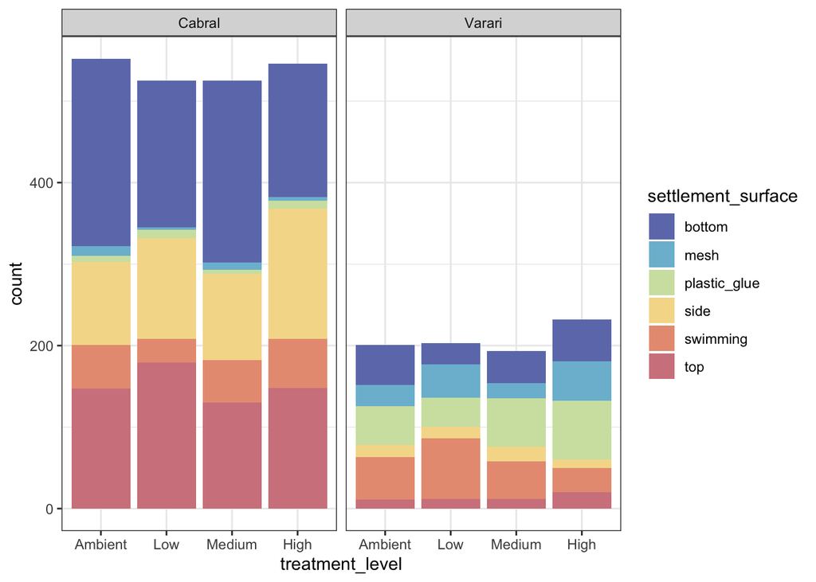

```r
###############################################
#### quick visualizations to plot patterns of settlement ####
###############################################
# first need to tidy and pivot the df to make count data and sampleID

settlement_counts_sum <- SettlementCounts %>%
  pivot_longer(cols = swimming:side, names_to = "settlement_surface" , values_to = "count")
##list which columns you want, colon includes "a" through "z", if just want one or two can use "|"
#to pivot, then rename the new column and the values that you are trying to get as the output

# group by treatment type and then summarize counts from there
#settlement_counts_sum <- settlement_counts_sum %>%
# group_by(treatment_level) %>%
#  summarize(sum_total=sum(count))

##calculating standard deviation
#settlement_counts_sum <- settlement_counts_sum %>%
# sd(count)

## separated by site
settlement_plot <- settlement_counts_sum %>%
  drop_na(site) %>%
  ggplot(aes(x=treatment_level,
             y=count,
             fill=settlement_surface)) +
  geom_col() +
  facet_wrap(~site) +
  theme_bw() +
  scale_fill_manual(values=pnw_palette("Sailboat")) +
  scale_x_discrete(limits=c("Ambient","Low","Medium", "High"))

settlement_plot
```

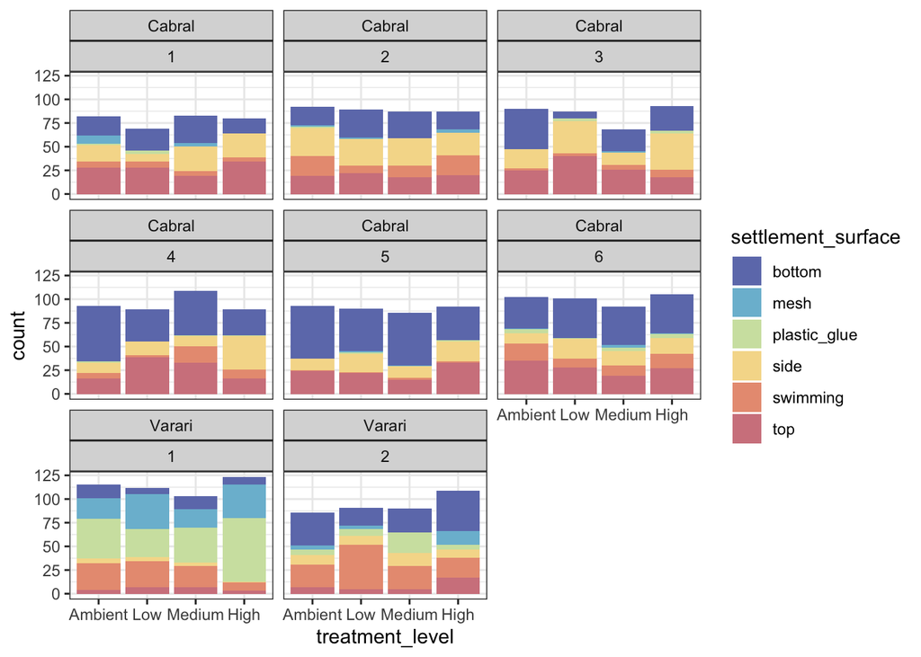

```r
ggsave(here("Outputs", "SettlementExperiment", "broadsettlement.jpg"),
       width=10, height=8)
#geom_errorbar(aes(x=treatment_level, ymin=count-sd, ymax=count+sd), width=0.4)

## separated by day and site to see if there are any differences across day
settlement_plot2 <- settlement_counts_sum %>%
  drop_na(spawning_day) %>%
  ggplot(aes(x=treatment_level,
             y=count,
             fill=settlement_surface)) +
  geom_col() +
  facet_wrap(site~spawning_day) +
  theme_bw() +
  scale_fill_manual(values=pnw_palette("Sailboat")) +
  scale_x_discrete(limits=c("Ambient","Low","Medium", "High"))
settlement_plot2
```

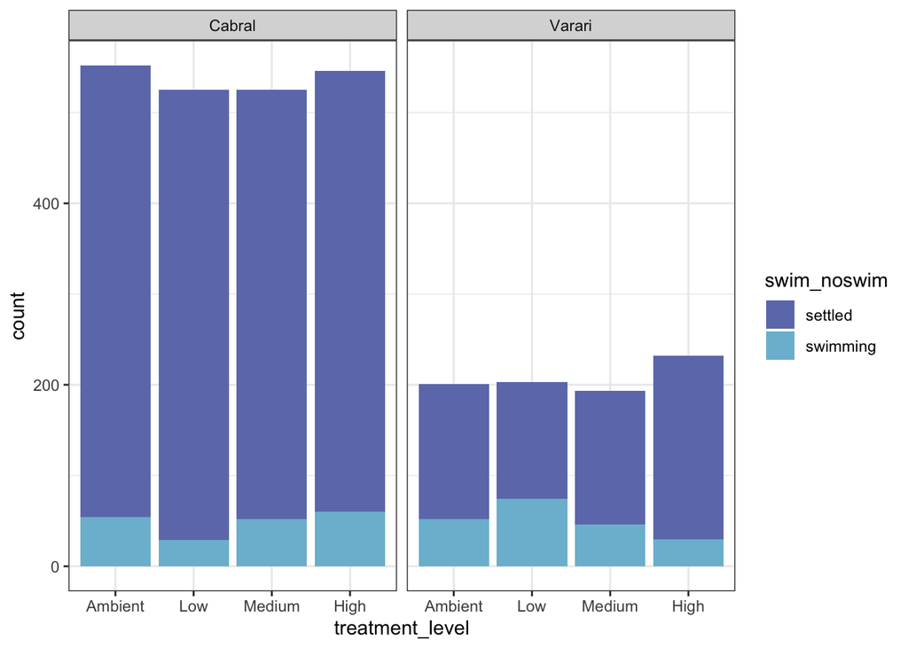

```r
ggsave(here("Outputs", "SettlementExperiment", "settlement_byday.jpg"),
       width=10, height=8)

# group by swimming vs any settled
settlement_counts_mutated <- SettlementCounts %>%
  mutate(settled = plastic_glue+mesh+top+bottom+side) %>%
  pivot_longer(cols = swimming|settled, names_to = "swim_noswim" , values_to = "count")

settlement_plot3 <- settlement_counts_mutated %>%
  drop_na(site) %>%
  ggplot(aes(x=treatment_level,
             y=count,
             fill=swim_noswim)) +
  geom_col() +
  facet_wrap(~site) +
  theme_bw() +
  scale_fill_manual(values=pnw_palette("Sailboat")) +
  scale_x_discrete(limits=c("Ambient","Low","Medium", "High"))

settlement_plot3
```

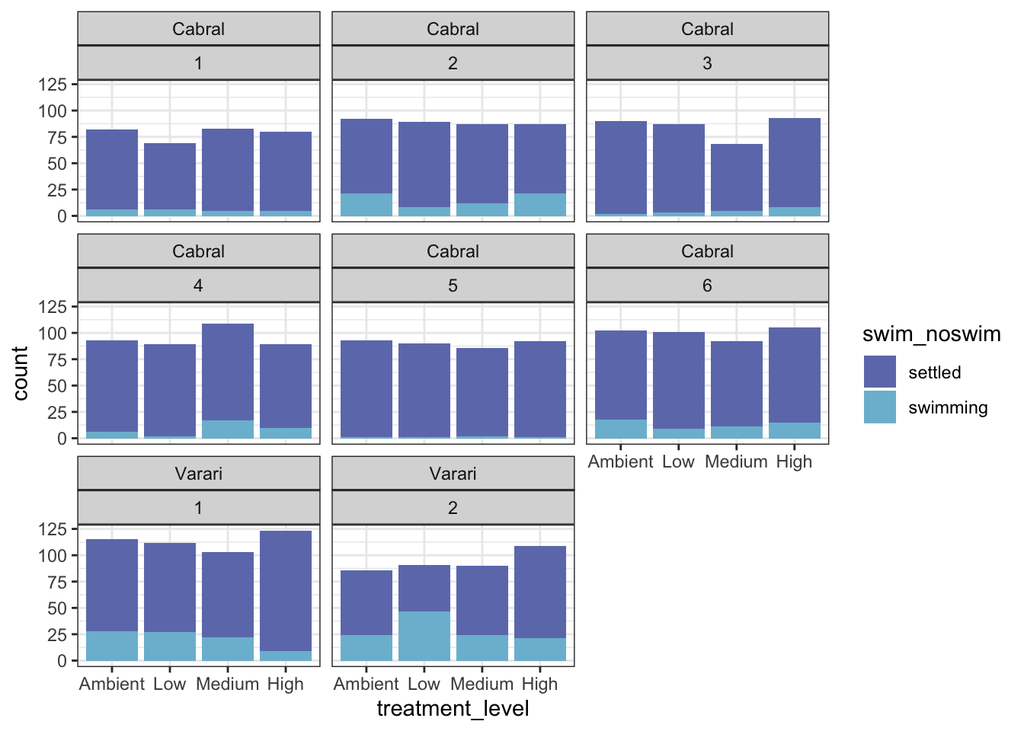

```r
ggsave(here("Outputs", "SettlementExperiment", "settlement_SwimnoSwim.jpg"),
       width=10, height=8)

settlement_plot4 <- settlement_counts_mutated %>%
  drop_na(spawning_day, site) %>%
  ggplot(aes(x=treatment_level,
             y=count,
             fill=swim_noswim)) +
  geom_col() +
  facet_wrap(site~spawning_day) +
  theme_bw() +
  scale_fill_manual(values=pnw_palette("Sailboat")) +
  scale_x_discrete(limits=c("Ambient","Low","Medium", "High"))

settlement_plot4
```

```r
ggsave(here("Outputs", "SettlementExperiment", "settlement_SwimnoSwim_perday.jpg"),
       width=10, height=8)
```

### More plots and some models? data exploration

```r
#### try making an ANOVA ####

SettlementCounts1 <- SettlementCount_updated %>%
  filter(spawning_day==2)

SettlementCounts2 <- SettlementCount_updated %>%
  filter(spawning_day==3)

anova_settlement <- aov(settled ~ treatment_level, data=SettlementCount_updated)
summary(anova_settlement)
```

```
##                  Df Sum Sq Mean Sq F value Pr(>F)
## treatment_level   3   35.1    11.7   0.959  0.414
## Residuals       159 1939.6    12.2
```

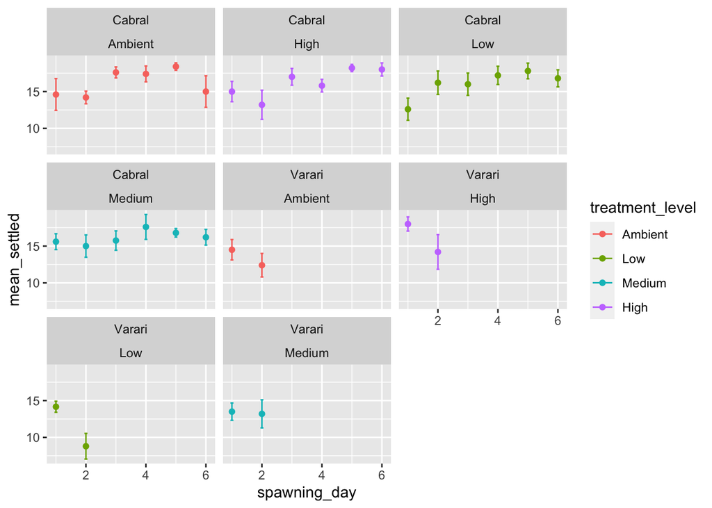

```r
### if do lmer, use anova rather than summary

## try to isolate difference between just ambient and low or med and high treatments for day 3


### not sure what is happening here
plot <- SettlementCount_updated %>%
  ggplot(aes(x=treatment_level, y=settled, color=treatmentID_rep)) +
  geom_point() +
  scale_x_discrete(limits=c("Ambient","Low","Medium", "High"))

SettlementCount_SEMean <- SettlementCount_updated %>%
  drop_na(site) %>%
  group_by(spawning_day, treatment_level, site) %>%
  summarize(mean_settled = mean(settled, na.rm=TRUE),
            mean_dead = mean(dead, na.rm=TRUE),
            mean_swimming = mean(swimming, na.rm=TRUE),
            se_settled = sd(settled, na.rm=TRUE)/sqrt(n()),
            se_dead = sd(dead, na.rm=TRUE)/sqrt(n()),
            se_swimming = sd(swimming, na.rm=TRUE)/sqrt(n()))

SettlementCounts_avgs <- SettlementCount_SEMean %>%
  ggplot(aes(x=spawning_day,
             y=mean_settled,
             color=treatment_level)) +
  geom_point() +
  geom_errorbar(aes(ymin=mean_settled-se_settled, ymax=mean_settled+se_settled), width=0.1) +
  scale_color_discrete(limits=c("Ambient","Low","Medium", "High"))  +
  facet_wrap(site~treatment_level)

SettlementCounts_avgs
```

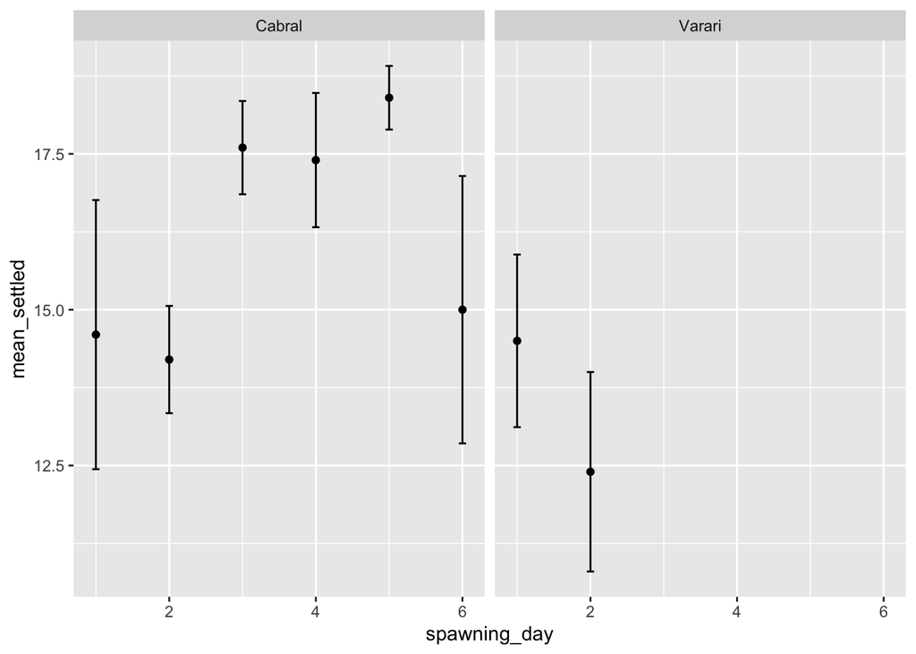

```r
ggsave(here("Outputs", "SettlementExperiment", "avg_counts_by_site_and_day.jpg"),
      width=10, height=8)



ambientonly_meansettlement <- SettlementCount_SEMean %>%
  filter(treatment_level== "Ambient") %>%
  ggplot(aes(x=spawning_day, y=mean_settled)) +
  geom_point() +
  geom_errorbar(aes(ymin=mean_settled-se_settled, ymax=mean_settled+se_settled), width=0.1)  +
  facet_wrap(~site)

ambientonly_meansettlement
```

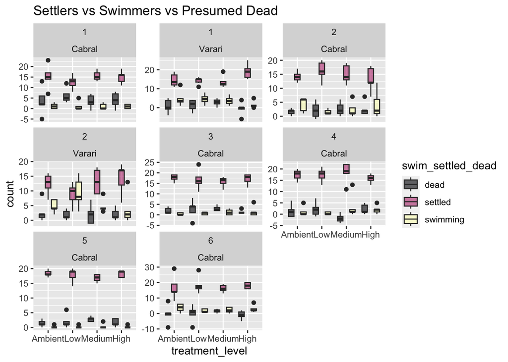

```r
ggsave(here("Outputs", "SettlementExperiment", "ambientonly_meansettlement.jpg"),
       width=10, height=8)
# scale_color_discrete(limits=c("Ambient","Low","Medium", "High"))
#facet_wrap(~treatment_level)

## errors and percent averages across replicates
## box plot of total settlers
settlement_counts_mutated <- SettlementCount_updated %>%
  mutate(settled = plastic_glue+mesh+top+bottom+side) %>%
  mutate(dead=20-(swimming+settled)) %>%
  pivot_longer(cols = swimming|dead|settled, names_to = "swim_settled_dead" , values_to = "count")

settlement_counts_mutated1 <- settlement_counts_mutated %>%
  drop_na(spawning_day) %>%
  ggplot(aes(x=treatment_level,
             y=count,
             fill=swim_settled_dead)) +
  geom_boxplot() +
  scale_fill_viridis(discrete = TRUE, alpha=0.6, option="A") +
  ggtitle("Settlers vs Swimmers vs Presumed Dead") +
  facet_wrap(spawning_day~site, scales ="free_y") +
  scale_x_discrete(limits=c("Ambient","Low","Medium", "High"))

settlement_counts_mutated1
```

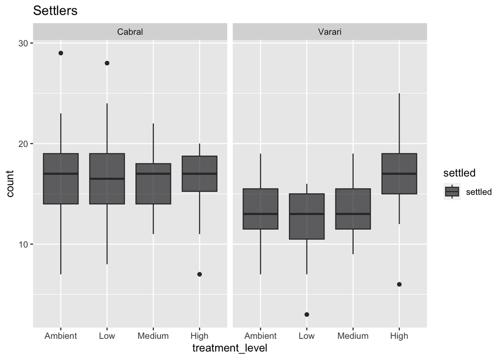

```r
ggsave(here("Outputs", "SettlementExperiment", "boxplots.jpg"),
       width=10, height=8)

# just the settlers
settlement_counts_mutated2 <- SettlementCount_updated %>%
  mutate(settled = plastic_glue+mesh+top+bottom+side) %>%
  pivot_longer(cols = settled, names_to = "settled" , values_to = "count") %>%
  drop_na(site)

settlement_counts_mutated_plot2 <- settlement_counts_mutated2 %>%
  ggplot(aes(x=treatment_level, y=count, fill=settled)) +
  geom_boxplot() +
  scale_fill_viridis(discrete = TRUE, alpha=0.6, option="A") +
  ggtitle("Settlers") +
  scale_x_discrete(limits=c("Ambient","Low","Medium", "High")) +
  facet_wrap(~site)

settlement_counts_mutated_plot2
```

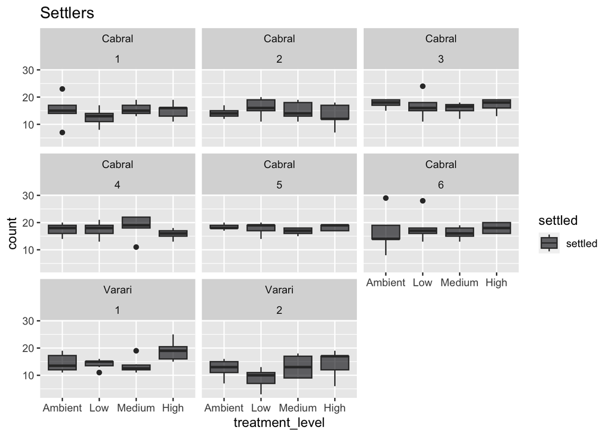

```r
ggsave(here("Outputs", "SettlementExperiment", "boxplots2.jpg"),
       width=10, height=8)

settlement_by_day <- settlement_counts_mutated2 %>%
  ggplot(aes(x=treatment_level,
             y=count,
             fill=settled)) +
  geom_boxplot() +
  scale_fill_viridis(discrete = TRUE, alpha=0.6, option="A") +
  facet_wrap(site~spawning_day) +
  ggtitle("Settlers") +
  scale_x_discrete(limits=c("Ambient","Low","Medium", "High"))
settlement_by_day
```

```r
ggsave(here("Outputs", "SettlementExperiment", "boxplots3_byday.jpg"),
       width=10, height=8)
```

# AUGUST 2024 - THESIS REVISIT for Chapter TWO

### For time being, forget about treatment blocks and days and combine all results together for settlement experiment

- Goal: to test silicate on the x axis and *expected proportions* of settlers on the y

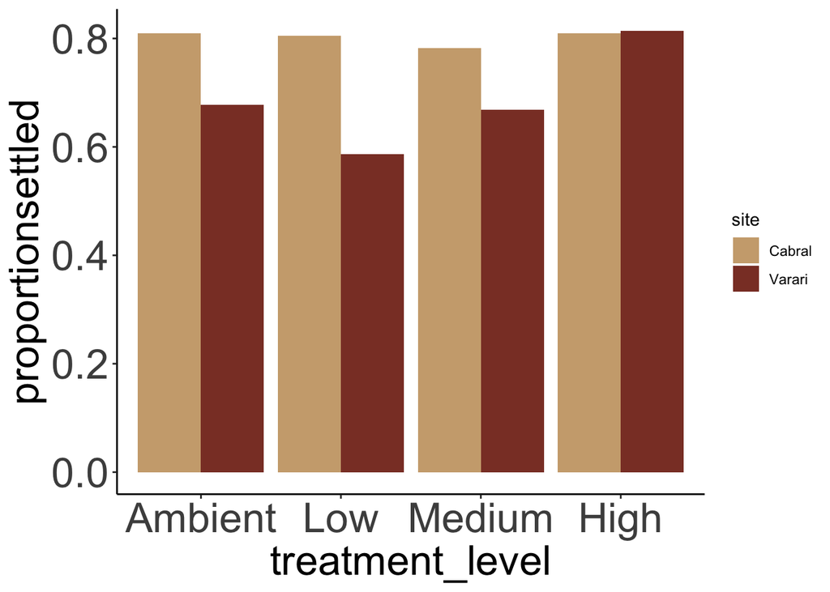

```r
###################################
### first separate out by sites to add in total possible settlers column
###################################

SettlementCounts_editV <- SettlementCount_updated %>%
  filter(site=="Varari") %>%
  dplyr::select(-c("notes", "swimming":"spawning_day", "rep_number", "treatmentID_rep", "countcheck")) %>%
  group_by(treatment_level, site) %>%
  dplyr::summarize(settled2 = sum(settled)) %>%
  dplyr::mutate(totalpossible = 20 * 11) %>%
  dplyr::mutate(proportionsettled = settled2 / totalpossible)

SettlementCount_editC <- SettlementCount_updated %>%
  filter(site=="Cabral") %>%
  dplyr::select(-c("notes", "swimming":"spawning_day", "rep_number", "treatmentID_rep", "countcheck")) %>%
  group_by(treatment_level, site) %>%
  dplyr::summarize(settled2 = sum(settled),
                   totalpossible=20*30,
                   proportionsettled=settled2/totalpossible,
                   avgproportion = mean(proportionsettled),
                   seproportion = sd(proportionsettled) / sqrt(n()))

###################################
### rejoin new dfs
###################################

SettlementCounts_joined <- SettlementCount_editC %>%
  full_join(SettlementCounts_editV)


###################################
### plot
###################################

SettlementCounts_plotted <- SettlementCounts_joined %>%
  ggplot(aes(x=treatment_level,
             y=proportionsettled,
             fill=site)) +
  geom_col(position = position_dodge()) + ##how to get fill variable next to each other rather than stacked
  scale_x_discrete(limits = c("Ambient", "Low", "Medium", "High")) +
  scale_fill_manual(values=c("burlywood3", "coral4"),
                    limits=c("Cabral", "Varari")) +
  theme_classic() +
  theme(axis.text.x=element_text(size=25),
        axis.text.y=element_text(size=25),
        axis.title.x=element_text(size=25),
        axis.title.y=element_text(size=25))

SettlementCounts_plotted
```

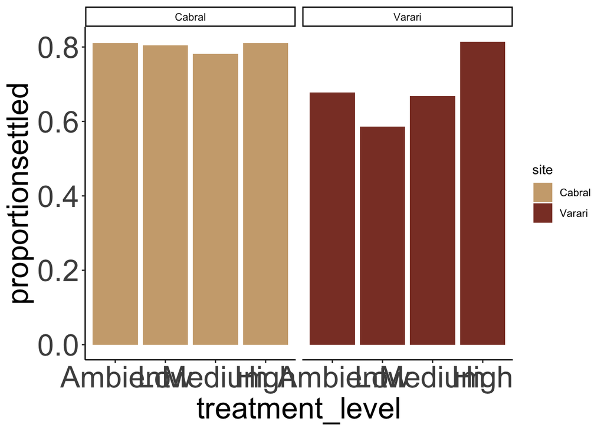

```r
ggsave(here("Outputs", "SettlementExperiment", "Prelim", "SettlementCounts_proportion1.jpg"),
       width=10, height=8)

SettlementCounts_plotted2 <- SettlementCounts_joined %>%
  ggplot(aes(x=treatment_level,
             y=proportionsettled,
             fill=site)) +
  geom_col() +
  scale_x_discrete(limits = c("Ambient", "Low", "Medium", "High")) +
  scale_fill_manual(values=c("burlywood3", "coral4"),
                    limits=c("Cabral", "Varari")) +
  facet_wrap(~site) +
  theme_classic() +
  theme(axis.text.x=element_text(size=25),
        axis.text.y=element_text(size=25),
        axis.title.x=element_text(size=25),
        axis.title.y=element_text(size=25))

SettlementCounts_plotted2
```

```r
ggsave(here("Outputs", "SettlementExperiment", "Prelim", "SettlementCounts_proportion2.jpg"),
       width=10, height=8)


###################################
### Run a chi-squared test to see if those are real differences
###################################

# Create a contingency table of counts for each combination of treatment_level and site
SettlementCounts_joined_V <- SettlementCounts_joined %>%
  filter(site=="Varari")

contingency_table_V <- table(SettlementCounts_joined_V$treatment_level, SettlementCounts_joined_V$proportionsettled)

# Perform the Chi-Square test
chi_sq_test <- chisq.test(contingency_table_V)

chi_sq_test
```

```
##
##  Pearson's Chi-squared test
##
## data:  contingency_table_V
## X-squared = 12, df = 9, p-value = 0.2133
```

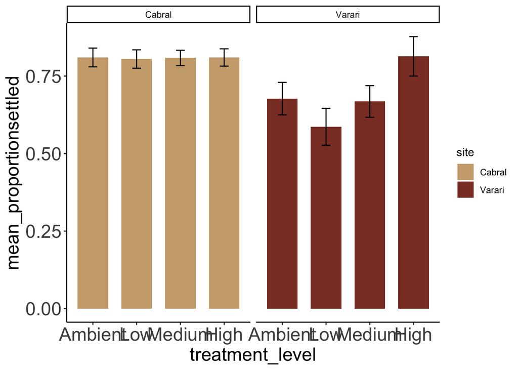

```r
#####################################
## what would above plot look like as the average proportion with error bars instead of the total proportion across everything?
#####################################

### edit dfs

#SettlementCounts_editV2 <- SettlementCounts %>%
 # filter(site=="Varari") %>%
 # dplyr::select(-c("notes", "swimming":"side", "countcheck")) %>%
#  group_by(treatment_level, site) %>%
 # dplyr::summarize(mean_settled = mean(settled)) %>%
#  dplyr::mutate(total_possible = if_else(spawning_day == 2 & treatment_level == "High", 20 * 6,
 #                                        if_else(spawning_day == 1, 20 * 6, 20 * 5))) %>%
 # dplyr::mutate(mean_proportionsettled = mean_settled / total_possible) %>%
 # ungroup() %>%
 # dplyr::mutate(se = sd(mean_proportionsettled) / sqrt(n()))
##################

###################################
### need avg proportion per treatment
### calculate the proportion BEFORE grouping so that have individual prop for each data point, and THEN average
###################################

SettlementCounts_bothsites <- SettlementCount_updated %>%
  dplyr::select(-c("notes", "countcheck")) %>%
  dplyr::mutate(proportion_settled = settled/20) %>%
  group_by(treatment_level, site) %>%
  dplyr::summarize(mean_proportionsettled=mean(proportion_settled),
                se = sd(proportion_settled) / sqrt(n())) %>%
  ungroup()

###################################
### now plot with SE bars
###################################
SettlementCounts_plotted3 <- SettlementCounts_bothsites %>%
  ggplot(aes(x=treatment_level,
             y=mean_proportionsettled,
             fill=site)) +
  geom_col(position = position_dodge(), width = 0.7) +
  geom_errorbar(aes(ymin = mean_proportionsettled - se,
                    ymax = mean_proportionsettled + se),
                 width = 0.2,
                position = position_dodge(0.7)) +
  scale_x_discrete(limits = c("Ambient", "Low", "Medium", "High")) +
  scale_fill_manual(values=c("burlywood3", "coral4"),
                    limits=c("Cabral", "Varari")) +
  facet_wrap(~site) +
  theme_classic() +
  theme(axis.text.x=element_text(size=18),
        axis.text.y=element_text(size=18),
        axis.title.x=element_text(size=18),
        axis.title.y=element_text(size=18))

SettlementCounts_plotted3
```

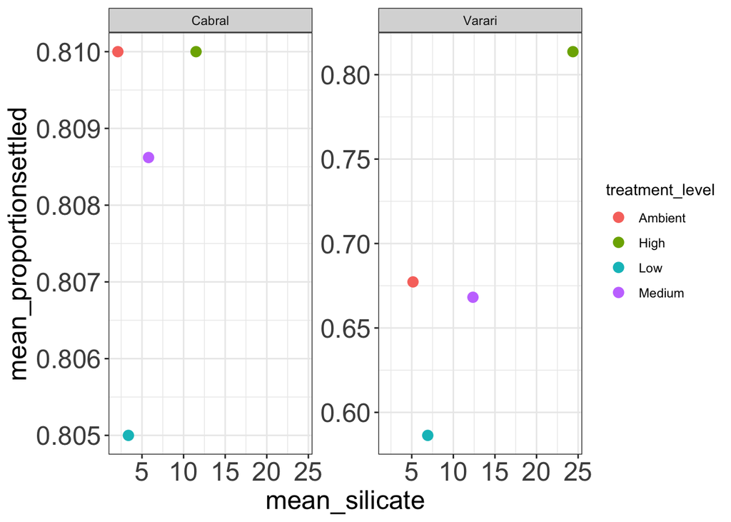

```r
ggsave(here("Outputs", "SettlementExperiment", "Prelim", "SettlementCounts_avgproportion.jpg"),
       width=10, height=8)

###################################
### plot with silicate
###################################

SettlementCounts_bothsites2 <- SettlementCount_updated %>%
  dplyr::select(-c("notes", "swimming":"side", "countcheck")) %>%
  dplyr::mutate(proportion_settled = settled/20) %>%
  group_by(treatment_level, site) %>%
  dplyr::summarize(mean_silicate = mean(silicate),
                   mean_proportionsettled=mean(proportion_settled),
                   se = sd(proportion_settled) / sqrt(n())) %>%
  ungroup()


SettlementCounts_plotted4 <- SettlementCounts_bothsites2 %>%
  ggplot(aes(x=mean_silicate,
             y=mean_proportionsettled,
             color=treatment_level)) +
  geom_point(size=3) +
  scale_fill_manual(values=c("burlywood3", "coral4"),
                    limits=c("Cabral", "Varari")) +
  facet_wrap(~site, scales="free_y") +
  theme_bw() +
  theme(axis.text.x=element_text(size=18),
        axis.text.y=element_text(size=18),
        axis.title.x=element_text(size=18),
        axis.title.y=element_text(size=18))

SettlementCounts_plotted4
```

### Plots using silicate as the main x-axis

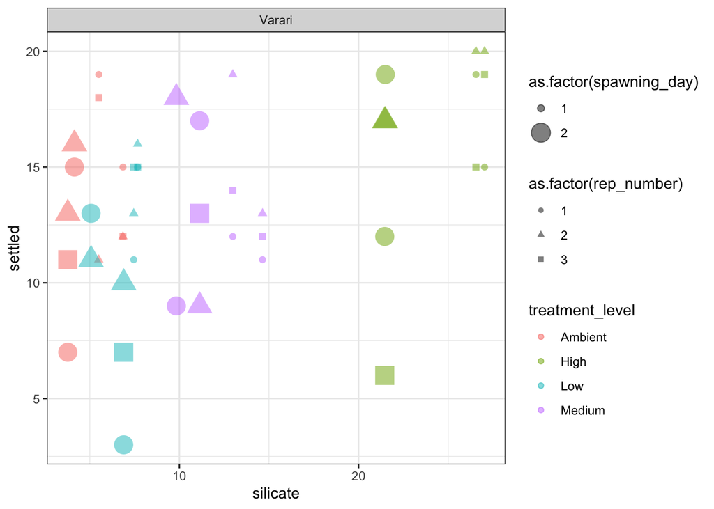

```r
###########
## by treatment level
silicate_settlement1 <- SettlementCount_updated %>%
  filter(site=="Varari") %>%
  ggplot(aes(x=silicate,
             y=settled,
             color=treatment_level,
             shape = as.factor(rep_number),
             size=as.factor(spawning_day))) +
  geom_point(alpha=0.5)  +
  facet_wrap(~site, scales="free_x") +
  theme_bw()

silicate_settlement1
```

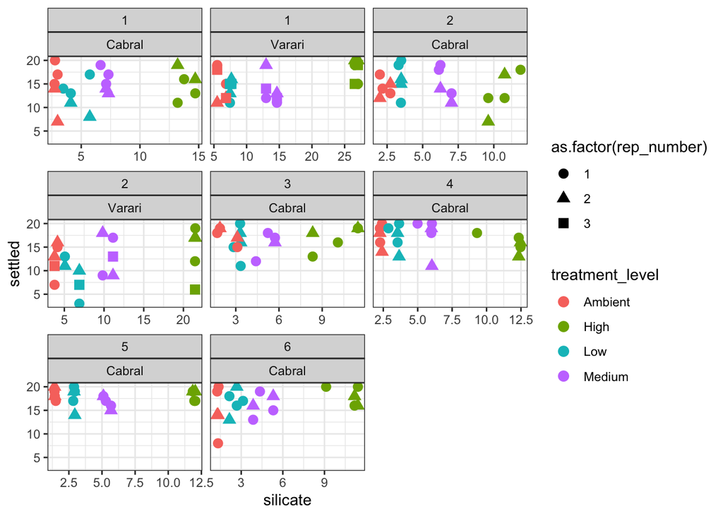

```r
##########
## by spawning day
silicate_settlement2 <- SettlementCount_updated %>%
  ggplot(aes(x=silicate,
             y=settled,
             color=treatment_level,
             shape = as.factor(rep_number))) +
  geom_point(size=3)  +
  facet_wrap(spawning_day~site, scales="free_x") +
  theme_bw()


silicate_settlement2
```

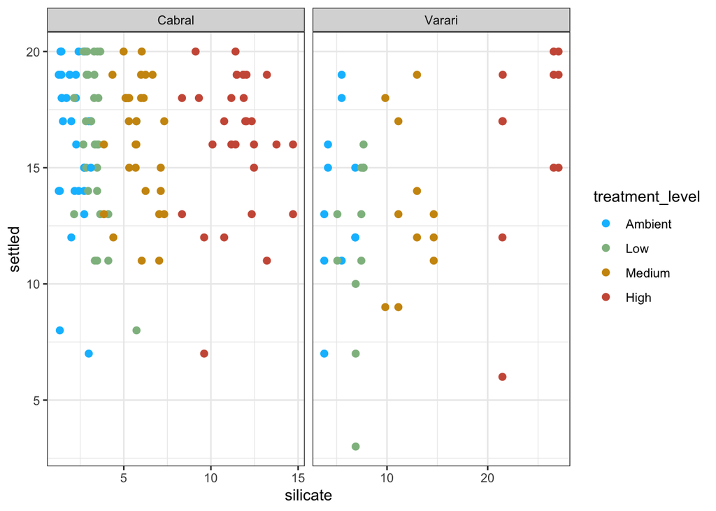

```r
##########
## general
silicate_settlement3 <- SettlementCount_updated %>%
  ggplot(aes(x=silicate,
             y=settled,
             color=treatment_level)) +
  geom_point(size=2)  +
  scale_color_manual(values=c("deepskyblue", "darkseagreen", "darkgoldenrod3", "coral3"),
                    limits=c("Ambient", "Low", "Medium", "High")) +
  facet_wrap(~site, scales="free_x") +
  theme_bw()


silicate_settlement3
```

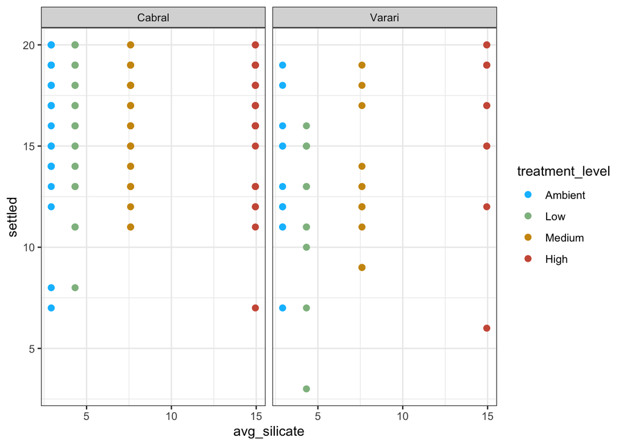

```r
ggsave(here("Outputs", "SettlementExperiment", "Prelim", "silicate_settled.jpg"),
       width=10, height=8)

########################################
## take avg silciate per treatment
########################################

SettlementCount_silicateavg <- SettlementCount_updated %>%
  group_by(treatment_level) %>%
  mutate(avg_silicate= mean(silicate))

silicate_settlement4 <- SettlementCount_silicateavg %>%
  ggplot(aes(x=avg_silicate,
             y=settled,
             color=treatment_level)) +
  geom_point(size=2)  +
  scale_color_manual(values=c("deepskyblue", "darkseagreen", "darkgoldenrod3", "coral3"),
                    limits=c("Ambient", "Low", "Medium", "High")) +
  facet_wrap(~site, scales="free_x") +
  theme_bw()

silicate_settlement4
```

### Create plots for other nutrients as well (NN and P)

- replaced silicate with NN and P

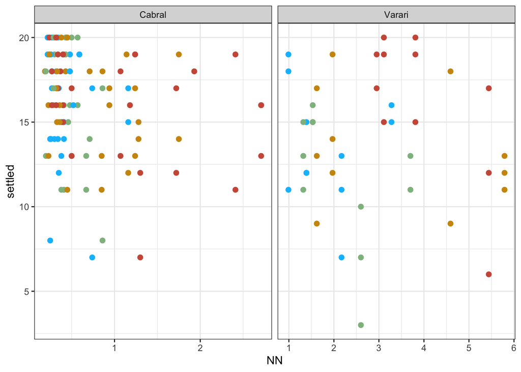

```r
nitrate_settlement <- SettlementCount_updated %>%
  ggplot(aes(x=NN,
             y=settled,
             color=treatment_level)) +
  geom_point(size=2)  +
  facet_wrap(~site, scales="free_x") +
  scale_color_manual(values=c("deepskyblue", "darkseagreen", "darkgoldenrod3", "coral3"),
                    limits=c("Ambient", "Low", "Medium", "High")) +
  guides(color = "none") +
  theme_bw()

nitrate_settlement
```

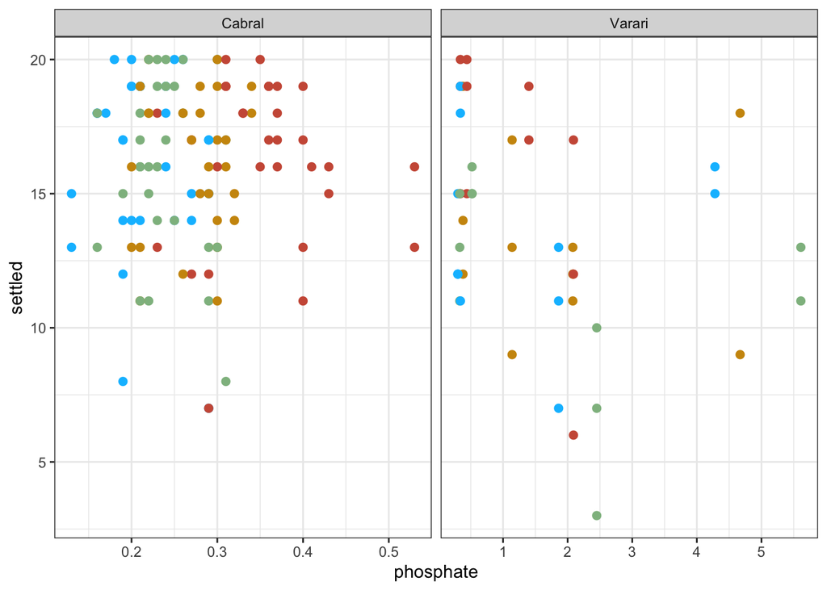

```r
ggsave(here("Outputs", "SettlementExperiment", "Prelim", "NN_settled.jpg"),
       width=10, height=8)


phosphate_settlement <- SettlementCount_updated %>%
  ggplot(aes(x=phosphate,
             y=settled,
             color=treatment_level)) +
  geom_point(size=2)  +
  facet_wrap(~site, scales="free_x") +
  scale_color_manual(values=c("deepskyblue", "darkseagreen", "darkgoldenrod3", "coral3"),
                    limits=c("Ambient", "Low", "Medium", "High")) +
  guides(color = "none") +
  theme_bw()

phosphate_settlement
```

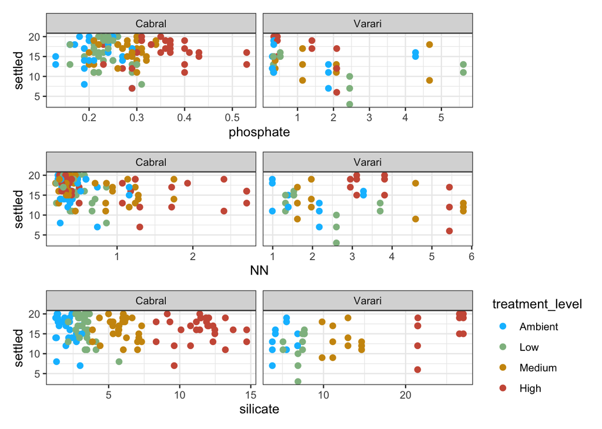

```r
ggsave(here("Outputs", "SettlementExperiment", "Prelim", "PO4_settled.jpg"),
       width=10, height=8)

########################################
## patch all 3 env param plots together
########################################

phosphate_settlement / nitrate_settlement / silicate_settlement3
```

```r
ggsave(here("Outputs", "SettlementExperiment", "Prelim", "EnvParamsPlot_vs_settled.jpg"),
       width=10, height=15)
```

### plot day on x and settled on y, color by treatment

- some of the points are hidden behind others (like the Medium counts for Day 1 at Cabral for example)

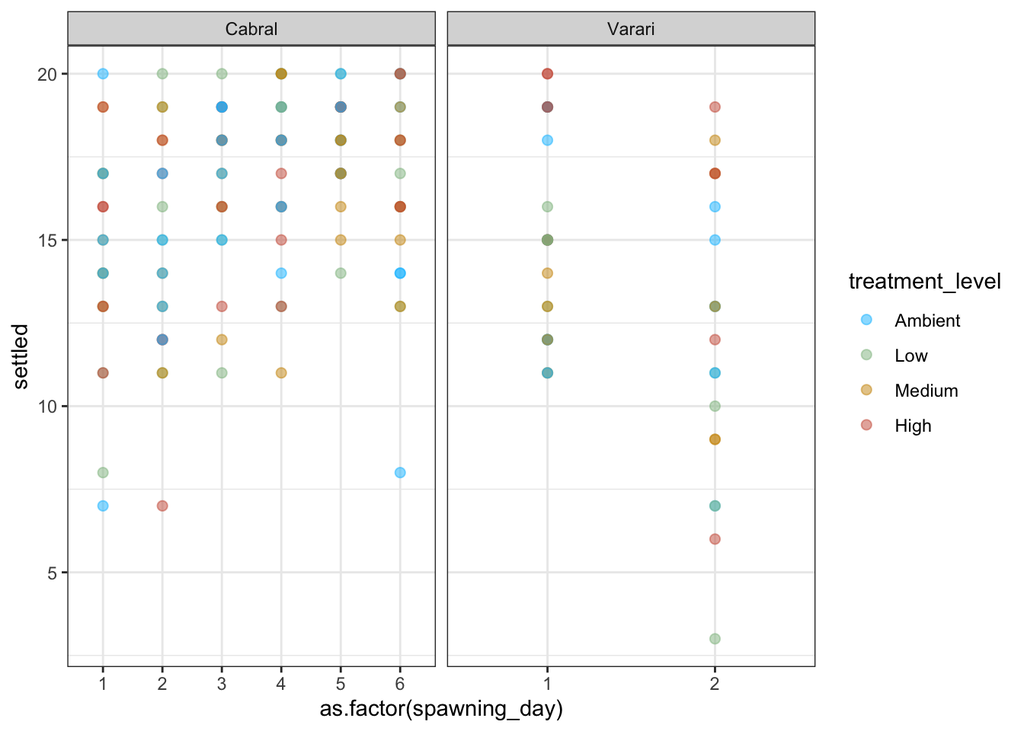

```r
perday_settlement <- SettlementCount_updated %>%
  ggplot(aes(x=as.factor(spawning_day),
             y=settled,
             color=treatment_level)) +
  geom_point(size=2, alpha=0.5)  +
  facet_wrap(~site, scales="free_x") +
  scale_color_manual(values=c("deepskyblue", "darkseagreen", "darkgoldenrod3", "coral3"),
                    limits=c("Ambient", "Low", "Medium", "High")) +
  #guides(color = "none") +
  theme_bw()

perday_settlement
```

### plot day on x and settled on y, color by treatment AND facet by treatment

- analysis: ambient day 1 and 6 are more variable than 2-4 BUT opposite in Medium at Cabral, High and low kinda have the same variance across
- Varari has lower settlement in day 2 compared to day 1 in ambient and low treatments but not necessarily in medium and high

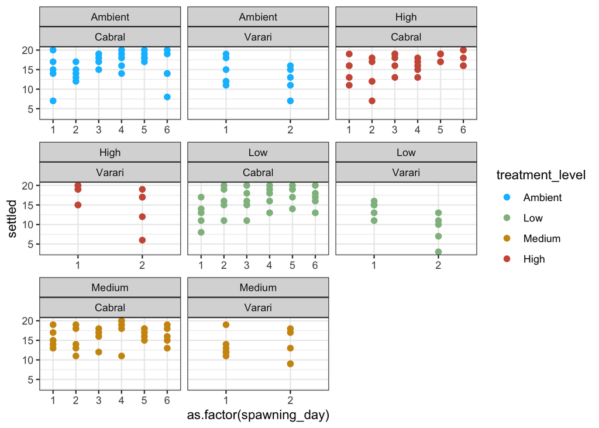

```r
#########
## facet by treatment

perday_settlement_treatmentfacet <- SettlementCount_updated %>%
  ggplot(aes(x=as.factor(spawning_day),
             y=settled,
             color=treatment_level)) +
  geom_point(size=2)  +
  facet_wrap(treatment_level~site, scales="free_x") +
  scale_color_manual(values=c("deepskyblue", "darkseagreen", "darkgoldenrod3", "coral3"),
                    limits=c("Ambient", "Low", "Medium", "High")) +
  #guides(color = "none") +
  theme_bw()

perday_settlement_treatmentfacet
```

### Plot based on proportion settled by treatment

- Notes from Craig during meeting (Aug 7th) - focus on Cabral first since 6 days vs only 2 days at Varari

```r
SettlementCounts_Cabral <- SettlementCount_updated %>%
  filter(site=="Cabral") %>%
  dplyr::select(-c("notes", "rep_number", "treatmentID_rep", "countcheck")) %>%
  group_by(treatment_level, site, spawning_day) %>%
  dplyr::summarize(settled2 = sum(settled),
                   totalpossible=20*5,
                   proportionsettled=settled2/totalpossible)

## model =
Cabralsettlement_model <- lmer(proportionsettled~treatment_level + (1|spawning_day), data =SettlementCounts_Cabral)

summary(Cabralsettlement_model)
```

```
## Linear mixed model fit by REML. t-tests use Satterthwaite's method [
## lmerModLmerTest]
## Formula: proportionsettled ~ treatment_level + (1 | spawning_day)
##    Data: SettlementCounts_Cabral
##
## REML criterion at convergence: -34.9
##
## Scaled residuals:
##     Min      1Q  Median      3Q     Max
## -1.9734 -0.4333  0.2427  0.6627  1.0743
##
## Random effects:
##  Groups       Name        Variance Std.Dev.
##  spawning_day (Intercept) 0.003052 0.05524
##  Residual                 0.005290 0.07273
## Number of obs: 24, groups:  spawning_day, 6
##
## Fixed effects:
##                         Estimate Std. Error         df t value Pr(>|t|)
## (Intercept)            8.100e-01  3.729e-02  1.427e+01  21.724 2.45e-12 ***
## treatment_levelHigh    1.472e-16  4.199e-02  1.500e+01   0.000    1.000
## treatment_levelLow    -5.000e-03  4.199e-02  1.500e+01  -0.119    0.907
## treatment_levelMedium -2.833e-02  4.199e-02  1.500e+01  -0.675    0.510
## ---
## Signif. codes:  0 '***' 0.001 '**' 0.01 '*' 0.05 '.' 0.1 ' ' 1
##
## Correlation of Fixed Effects:
##             (Intr) trtm_H trtm_L
## trtmnt_lvlH -0.563
## trtmnt_lvlL -0.563  0.500
## trtmnt_lvlM -0.563  0.500  0.500
```

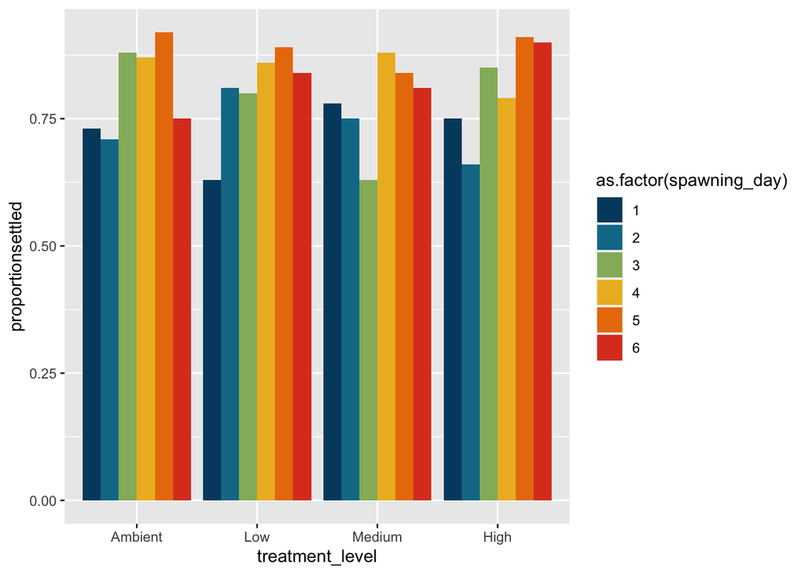

```r
## significant difference from ambient ??

Cabralsettlementplot <- SettlementCounts_Cabral %>%
  ggplot(aes(x=treatment_level,
             y=proportionsettled,
             fill=as.factor(spawning_day))) +
  geom_col(position = position_dodge()) +
  scale_x_discrete(limits = c("Ambient", "Low", "Medium", "High")) +
  scale_fill_manual(values=pnw_palette("Bay", n=6))


Cabralsettlementplot
```

#### EXTRA:

- not using as not well coded but saved for back-up

```r
#############
## Varari

SettlementCount_avgproportions_V<- SettlementCount_updated %>%
  filter(site=="Varari") %>%
  dplyr::select(-c("notes", "countcheck")) %>%
  group_by(treatment_level, site) %>%
  dplyr::summarize(total_settled = sum(settled),
                   mean_settled = mean(settled),
                   totalpossible_perbin = 20) %>%
  dplyr::mutate(total_possible= if_else(treatment_level == "High", 20 * 12, 20 * 11),
                proportion_settled = total_settled/total_possible,
                mean_proportionsettled=mean_settled/totalpossible_perbin) %>% #,
               # se = sd(settled / total_possible) / sqrt(n())) %>%
  ungroup()

#############
## Cabral

low_treatment_count <- SettlementCount_updated %>%
  filter(site=="Cabral") %>%
  filter(treatment_level == "Medium") %>%
  nrow()
low_treatment_count
```

```
## [1] 29
```

```r
SettlementCounts_editC2 <- SettlementCount_updated %>%
  filter(site=="Cabral") %>%
  dplyr::select(-c("notes", "countcheck")) %>%
  dplyr::mutate(proportion_settled = settled/20)


 # group_by(treatment_level, site) %>%
 # dplyr::mutate(se = sd(mean_proportionsettled) / sqrt(n()))


  SettlementCount_avgproportions2 <- SettlementCount_updated %>%
  group_by(treatment_level, site) %>%
  dplyr::summarize(mean_settled = mean(settled),
                   mean_silicate = mean(silicate)) %>%
  dplyr::mutate(
    total_possible = if_else(site == "Varari" & treatment_level == "High", 20 * 6, 20 * 5),
    mean_proportionsettled = mean_settled / total_possible,
    se = sd(mean_settled / total_possible) / sqrt(n())
  ) %>%
  ungroup()
```

### Notes for what to work on (March 2024)

```r
# add error bars
# load env data
# include random effect of tank and maybe table?
# make plots for salinity and count data
# figure out Tris calibrations to get pH calculations
# make plots for pH and count data
# add days 4 and 5 and hopefully 6 to see if there is a stronger pattern
# think about hourly effect of day 1-3 and also day of larval release
# plug in hypothetical, approximate nutrient values from respo data to see if pattern with nutrients
```